# Analysis on engagements on ads

Edwin Mutuma

7/2/2021

## a) Specifying the Data Analytic Question

To identify which individuals are are most likely to click on ads relating to an online cryptography course.

## b) Defining the Metric for Success

The project will be a success if the analysis narrows down to a set of individuals that have a high likelihood of clicking on the ads relating to an online cryptography course. Being able to come up with the best fits for these campaigns will be a huge success factor.

## c) Understanding the context

A Kenyan entrepreneur has created an online cryptography course and would want to advertise it on her blog. She seeks to target a set of individuals who can take up the course and a result, she has employed the services of a a data scientist to perform analysis and recommend on the individuals that have a high likelihood of clicking on ads on her blog.

## d) Recording the Experimental Design

For the project to be a success, the following steps will be followed: 1) Reading the data. 2) Finding and dealing with outliers, anomalies, and missing data within the dataset. 3) Performing univariate and bivariate analysis. 4) Providing a conclusion and recommendation.

## LOADING THE DATA

```r
ads <- read.csv("C:/Users/EMBU URBAN/Downloads/advertising.csv")
```

## CHECKING THE DATASET

Look at the top 5 entries of our dataset

```r
head(ads)
```

```
##   Daily.Time.Spent.on.Site Age Area.Income Daily.Internet.Usage
## 1                    68.95  35    61833.90               256.09
## 2                    80.23  31    68441.85               193.77
## 3                    69.47  26    59785.94               236.50
## 4                    74.15  29    54806.18               245.89
## 5                    68.37  35    73889.99               225.58
## 6                    59.99  23    59761.56               226.74
##                           Ad.Topic.Line           City Male    Country
## 1    Cloned 5thgeneration orchestration    Wrightburgh    0    Tunisia
## 2    Monitored national standardization      West Jodi    1      Nauru
## 3      Organic bottom-line service-desk       Davidton    0 San Marino
## 4 Triple-buffered reciprocal time-frame West Terrifurt    1      Italy
## 5         Robust logistical utilization   South Manuel    0    Iceland
## 6       Sharable client-driven software      Jamieberg    1     Norway
##             Timestamp Clicked.on.Ad
## 1 2016-03-27 00:53:11             0
## 2 2016-04-04 01:39:02             0
## 3 2016-03-13 20:35:42             0
## 4 2016-01-10 02:31:19             0
## 5 2016-06-03 03:36:18             0
## 6 2016-05-19 14:30:17             0
```

Looking at the bottom part of the data

```r
tail(ads)
```

```
##      Daily.Time.Spent.on.Site Age Area.Income Daily.Internet.Usage
## 995                     43.70  28    63126.96               173.01
## 996                     72.97  30    71384.57               208.58
## 997                     51.30  45    67782.17               134.42
## 998                     51.63  51    42415.72               120.37
## 999                     55.55  19    41920.79               187.95
## 1000                    45.01  26    29875.80               178.35
##                             Ad.Topic.Line          City Male
## 995         Front-line bifurcated ability  Nicholasland    0
## 996         Fundamental modular algorithm     Duffystad    1
## 997       Grass-roots cohesive monitoring   New Darlene    1
## 998          Expanded intangible solution South Jessica    1
## 999  Proactive bandwidth-monitored policy   West Steven    0
## 1000      Virtual 5thgeneration emulation   Ronniemouth    0
##                     Country           Timestamp Clicked.on.Ad
## 995                 Mayotte 2016-04-04 03:57:48             1
## 996                 Lebanon 2016-02-11 21:49:00             1
## 997  Bosnia and Herzegovina 2016-04-22 02:07:01             1
## 998                Mongolia 2016-02-01 17:24:57             1
## 999               Guatemala 2016-03-24 02:35:54             0
## 1000                 Brazil 2016-06-03 21:43:21             1
```

Look at the structure of the dataset

```r
str(ads)
```

```
## 'data.frame':    1000 obs. of  10 variables:
##  $ Daily.Time.Spent.on.Site: num  69 80.2 69.5 74.2 68.4 ...
##  $ Age                     : int  35 31 26 29 35 23 33 48 30 20 ...
##  $ Area.Income             : num  61834 68442 59786 54806 73890 ...
##  $ Daily.Internet.Usage    : num  256 194 236 246 226 ...
##  $ Ad.Topic.Line           : chr  "Cloned 5thgeneration orchestration" "Monitored national standardization" "Organic bottom-line service-desk" "Triple-buffered reciprocal time-frame" ...
##  $ City                    : chr  "Wrightburgh" "West Jodi" "Davidton" "West Terrifurt" ...
##  $ Male                    : int  0 1 0 1 0 1 0 1 1 1 ...
##  $ Country                 : chr  "Tunisia" "Nauru" "San Marino" "Italy" ...
##  $ Timestamp               : chr  "2016-03-27 00:53:11" "2016-04-04 01:39:02" "2016-03-13 20:35:42" "2016-01-10 02:31:19" ...
##  $ Clicked.on.Ad           : int  0 0 0 0 0 0 0 1 0 0 ...
```

Look at the description of the data.

```r
summary(ads)
```

```
##  Daily.Time.Spent.on.Site      Age         Area.Income    Daily.Internet.Usage
##  Min.   :32.60            Min.   :19.00   Min.   :13996   Min.   :104.8
##  1st Qu.:51.36            1st Qu.:29.00   1st Qu.:47032   1st Qu.:138.8
##  Median :68.22            Median :35.00   Median :57012   Median :183.1
##  Mean   :65.00            Mean   :36.01   Mean   :55000   Mean   :180.0
##  3rd Qu.:78.55            3rd Qu.:42.00   3rd Qu.:65471   3rd Qu.:218.8
##  Max.   :91.43            Max.   :61.00   Max.   :79485   Max.   :270.0
##  Ad.Topic.Line          City                Male         Country
##  Length:1000        Length:1000        Min.   :0.000   Length:1000
##  Class :character   Class :character   1st Qu.:0.000   Class :character
##  Mode  :character   Mode  :character   Median :0.000   Mode  :character
##                                        Mean   :0.481
##                                        3rd Qu.:1.000
##                                        Max.   :1.000
##   Timestamp         Clicked.on.Ad
##  Length:1000        Min.   :0.0
##  Class :character   1st Qu.:0.0
##  Mode  :character   Median :0.5
##                     Mean   :0.5
##                     3rd Qu.:1.0
##                     Max.   :1.0
```

```r
# Determining the no. of records in our dataset
#
dim(ads)
```

```
## [1] 1000   10
```

```r
# Checking the class of ads
class(ads)
```

```
## [1] "data.frame"
```

## TIDYING THE DATASET

```r
# Finding if there are any null values in the data
is.na(ads)
```

[output not shown]

[output cut: 1987 more lines]

```r
# Checking to see the specific number of missing values in our data
sum(is.na(ads))
```

```
## [1] 0
```

```r
colSums(is.na(ads))
```

```
## Daily.Time.Spent.on.Site                      Age              Area.Income
##                        0                        0                        0
##     Daily.Internet.Usage            Ad.Topic.Line                     City
##                        0                        0                        0
##                     Male                  Country                Timestamp
##                        0                        0                        0
##            Clicked.on.Ad
##                        0
```

There are no missing values in our data.

Checking for the consistency of our data

```r
duplicated(ads)
```

[output not shown]

[output cut: 69 more lines]

```r
# Checking to see the exact number of the duplicated values in our data
sum(duplicated(ads))
```

```
## [1] 0
```

Checking for outliers Plotting boxplots

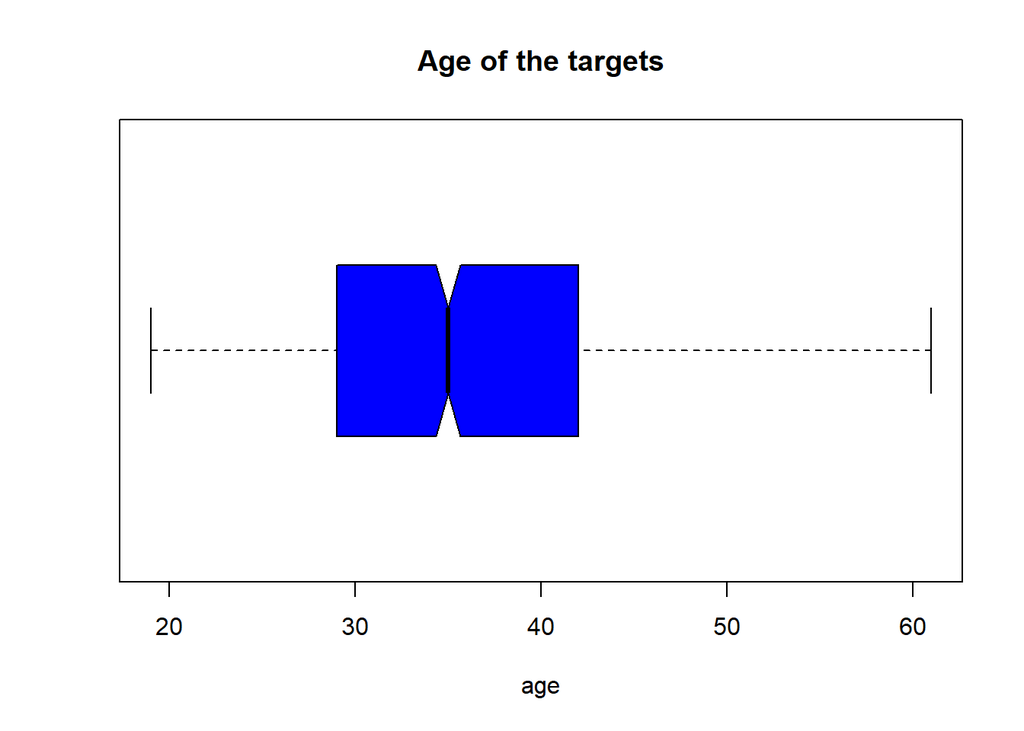

```r
boxplot(ads$Age,
         main = "Age of the targets",
         col = "Blue",
         border = "Black",
         horizontal = T,
         notch = T,
         ylab = "",
         xlab = "age")
```

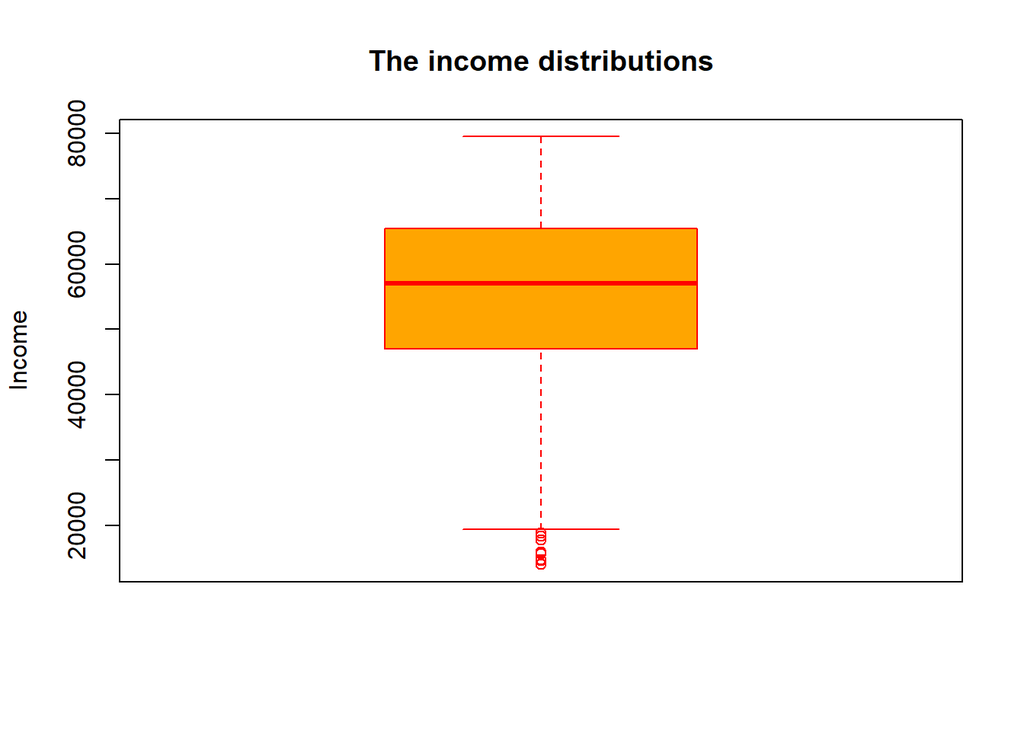

```r
boxplot(ads$Area.Income,
        main = "The income distributions",
        col = "Orange",
        border = "Red",
        ylab = "Income")
```

From the above plots, we can see that the incomes of the various users varied. However, the outliers we can see from the same are very well within the range given incomes of different people vary with different circumstances.

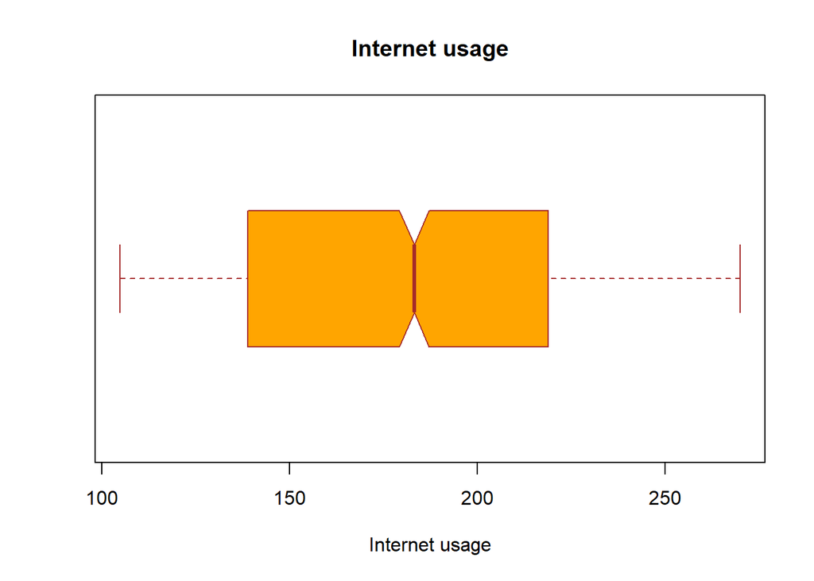

```r
boxplot(ads$Daily.Internet.Usage,
        main = "Internet usage",
        xlab = "Internet usage",
        horizontal = T,
        notch = T,
        col = "Orange",
        border = "Brown")
```

A couple of observations can be made from the dataset cleaning: 1) From the analysis performed above, there were no missing values. 2) All records were unique indicating that we had no duplicates in the data. 3) From the above plots, we can see that the incomes of the various users varied. However, the outliers we can see from the same are very well within the range given incomes of different people vary with different circumstances

## UNIVARIATE ANALYSIS

```r
summary(ads)
```

```
##  Daily.Time.Spent.on.Site      Age         Area.Income    Daily.Internet.Usage
##  Min.   :32.60            Min.   :19.00   Min.   :13996   Min.   :104.8
##  1st Qu.:51.36            1st Qu.:29.00   1st Qu.:47032   1st Qu.:138.8
##  Median :68.22            Median :35.00   Median :57012   Median :183.1
##  Mean   :65.00            Mean   :36.01   Mean   :55000   Mean   :180.0
##  3rd Qu.:78.55            3rd Qu.:42.00   3rd Qu.:65471   3rd Qu.:218.8
##  Max.   :91.43            Max.   :61.00   Max.   :79485   Max.   :270.0
##  Ad.Topic.Line          City                Male         Country
##  Length:1000        Length:1000        Min.   :0.000   Length:1000
##  Class :character   Class :character   1st Qu.:0.000   Class :character
##  Mode  :character   Mode  :character   Median :0.000   Mode  :character
##                                        Mean   :0.481
##                                        3rd Qu.:1.000
##                                        Max.   :1.000
##   Timestamp         Clicked.on.Ad
##  Length:1000        Min.   :0.0
##  Class :character   1st Qu.:0.0
##  Mode  :character   Median :0.5
##                     Mean   :0.5
##                     3rd Qu.:1.0
##                     Max.   :1.0
```

```r
library(psych)
describe(ads)
```

```
##                          vars    n     mean       sd   median  trimmed      mad
## Daily.Time.Spent.on.Site    1 1000    65.00    15.85    68.22    65.74    17.92
## Age                         2 1000    36.01     8.79    35.00    35.51     8.90
## Area.Income                 3 1000 55000.00 13414.63 57012.30 56038.94 13316.62
## Daily.Internet.Usage        4 1000   180.00    43.90   183.13   179.99    58.61
## Ad.Topic.Line*              5 1000   500.50   288.82   500.50   500.50   370.65
## City*                       6 1000   487.32   279.31   485.50   487.51   356.57
## Male                        7 1000     0.48     0.50     0.00     0.48     0.00
## Country*                    8 1000   116.41    69.94   114.50   115.82    89.70
## Timestamp*                  9 1000   500.50   288.82   500.50   500.50   370.65
## Clicked.on.Ad              10 1000     0.50     0.50     0.50     0.50     0.74
##                               min      max    range  skew kurtosis     se
## Daily.Time.Spent.on.Site    32.60    91.43    58.83 -0.37    -1.10   0.50
## Age                         19.00    61.00    42.00  0.48    -0.41   0.28
## Area.Income              13996.50 79484.80 65488.30 -0.65    -0.11 424.21
## Daily.Internet.Usage       104.78   269.96   165.18 -0.03    -1.28   1.39
## Ad.Topic.Line*               1.00  1000.00   999.00  0.00    -1.20   9.13
## City*                        1.00   969.00   968.00  0.00    -1.19   8.83
## Male                         0.00     1.00     1.00  0.08    -2.00   0.02
## Country*                     1.00   237.00   236.00  0.08    -1.23   2.21
## Timestamp*                   1.00  1000.00   999.00  0.00    -1.20   9.13
## Clicked.on.Ad                0.00     1.00     1.00  0.00    -2.00   0.02
```

```r
# Getting the means
colMeans(ads[sapply(ads,is.numeric)])
```

```
## Daily.Time.Spent.on.Site                      Age              Area.Income
##                  65.0002                  36.0090               55000.0001
##     Daily.Internet.Usage                     Male            Clicked.on.Ad
##                 180.0001                   0.4810                   0.5000
```

1. On average, the daily time spent on the site is 65
2. The average age of the user is 36 years.
3. The average area income is 55000.

```r
# Mode
getmode <- function(v) {
   uniqv <- unique(v)
   uniqv[which.max(tabulate(match(v, uniqv)))]
}

getmode(ads$Age)
```

```
## [1] 31
```

```r
getmode(ads$City)
```

```
## [1] "Lisamouth"
```

```r
getmode(ads$Male)
```

```
## [1] 0
```

```r
getmode(ads$Country)
```

```
## [1] "Czech Republic"
```

1. The age that is the most common of the users is 31 years
2. The City with the most repeat users is Lisamouth
3. The country that’s most repeated is Czech Republic
4. The most common gender in the data is Female

```r
median(ads$Daily.Time.Spent.on.Site)
```

```
## [1] 68.215
```

```r
median(ads$Age)
```

```
## [1] 35
```

```r
median(ads$Area.Income)
```

```
## [1] 57012.3
```

```r
median(ads$Daily.Internet.Usage)
```

```
## [1] 183.13
```

```r
### Range
range(ads$Daily.Time.Spent.on.Site)
```

```
## [1] 32.60 91.43
```

```r
range(ads$Age)
```

```
## [1] 19 61
```

```r
range(ads$Area.Income)
```

```
## [1] 13996.5 79484.8
```

```r
range(ads$Daily.Internet.Usage)
```

```
## [1] 104.78 269.96
```

```r
# Quantiles
quantile(ads$Daily.Time.Spent.on.Site)
```

```
##      0%     25%     50%     75%    100%
## 32.6000 51.3600 68.2150 78.5475 91.4300
```

```r
quantile(ads$Age)
```

```
##   0%  25%  50%  75% 100%
##   19   29   35   42   61
```

```r
quantile(ads$Area.Income)
```

```
##       0%      25%      50%      75%     100%
## 13996.50 47031.80 57012.30 65470.64 79484.80
```

```r
quantile(ads$Daily.Internet.Usage)
```

```
##       0%      25%      50%      75%     100%
## 104.7800 138.8300 183.1300 218.7925 269.9600
```

```r
### Variance
var(ads$Daily.Time.Spent.on.Site)
```

```
## [1] 251.3371
```

```r
var(ads$Age)
```

```
## [1] 77.18611
```

```r
var(ads$Area.Income)
```

```
## [1] 179952406
```

```r
var(ads$Daily.Internet.Usage)
```

```
## [1] 1927.415
```

```r
### Standard Deviation
sd(ads$Daily.Time.Spent.on.Site)
```

```
## [1] 15.85361
```

```r
sd(ads$Age)
```

```
## [1] 8.785562
```

```r
sd(ads$Area.Income)
```

```
## [1] 13414.63
```

```r
sd(ads$Daily.Internet.Usage)
```

```
## [1] 43.90234
```

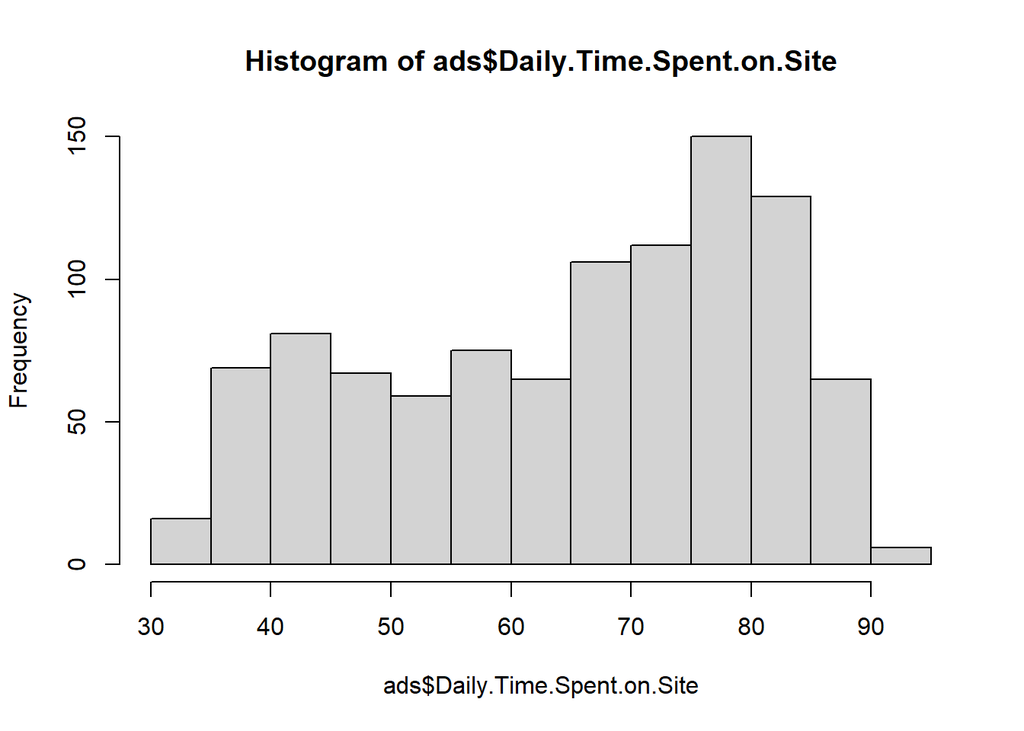

```r
# Histograms
hist(ads$Daily.Time.Spent.on.Site)
```

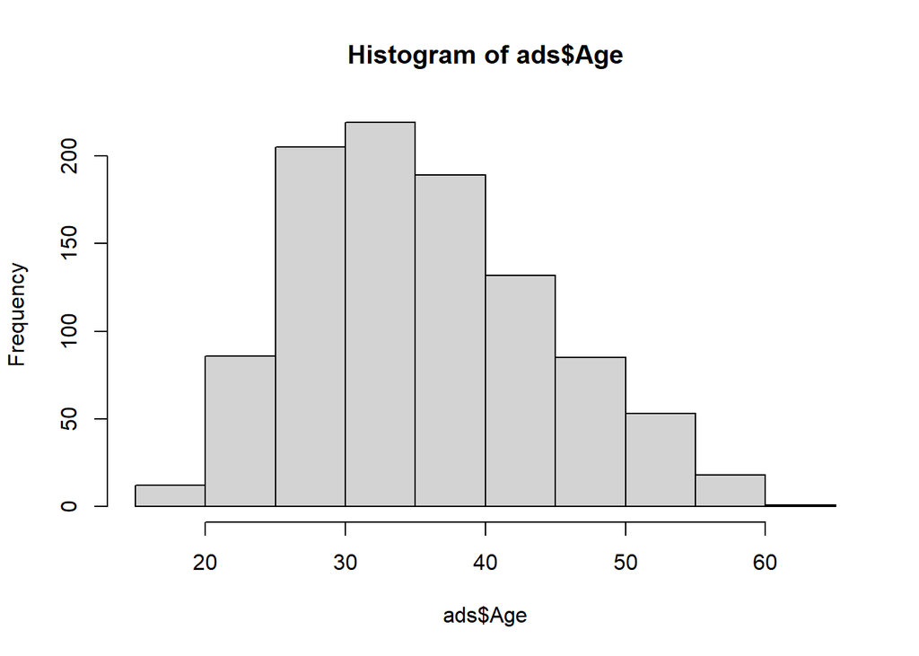

```r
hist(ads$Age)
```

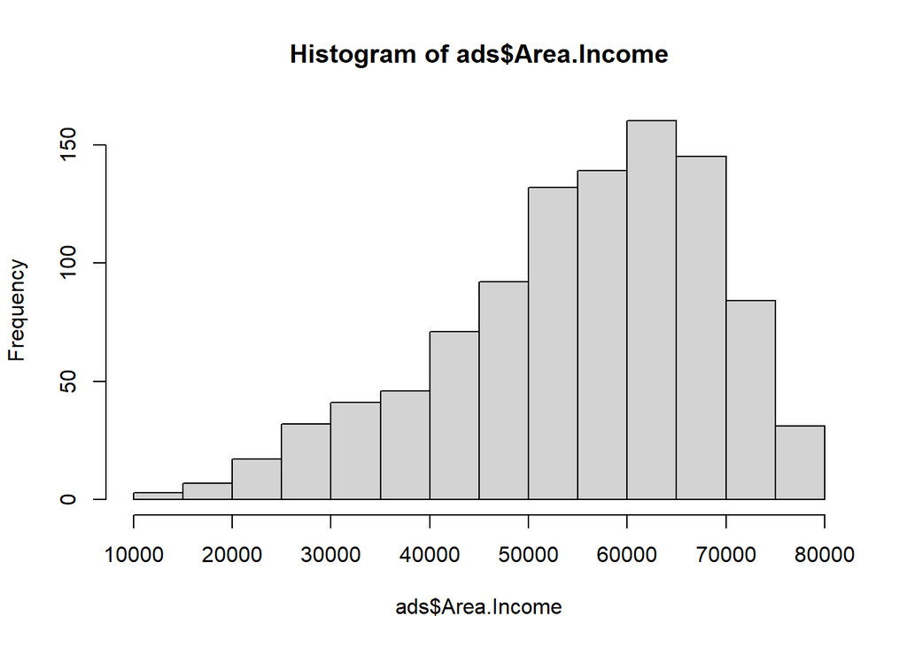

```r
hist(ads$Area.Income)
```

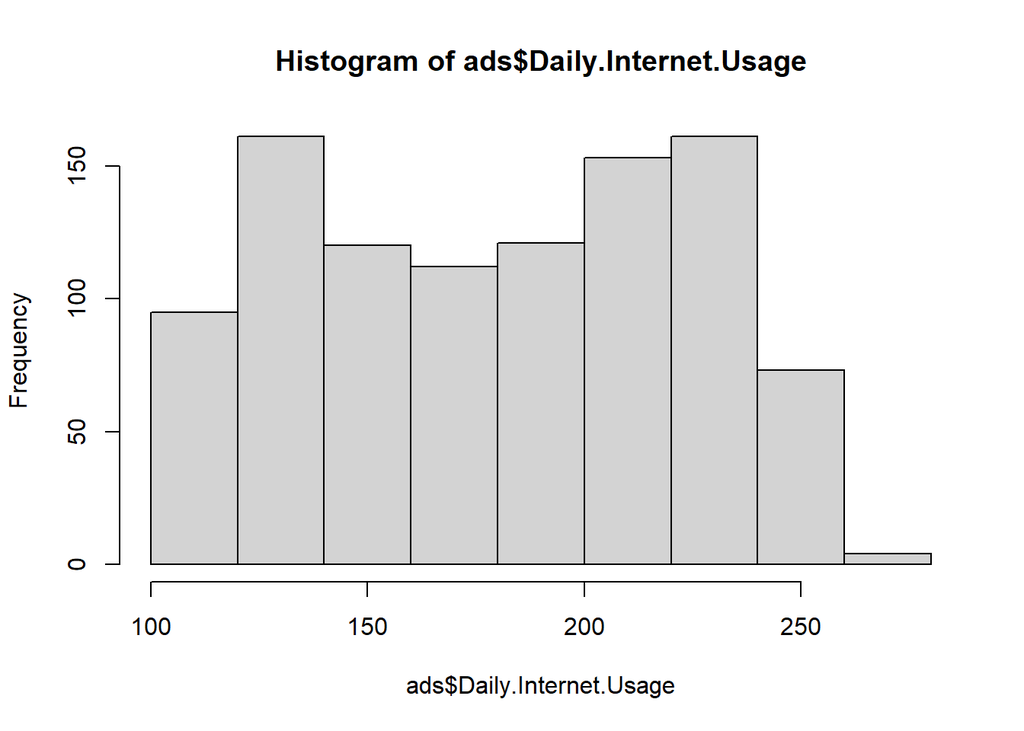

```r
hist(ads$Daily.Internet.Usage)
```

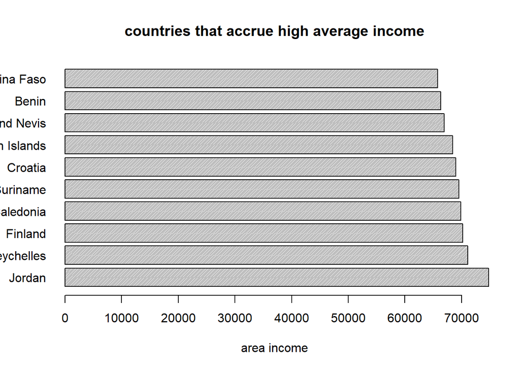

```r
# top 10 countries that accrue high average income
avg.country = aggregate(ads$Area.Income, by=list(ads$Country), FUN=mean)
cou.top10<-head(avg.country[order(avg.country$x,decreasing = TRUE), ],10)
barplot(cou.top10$x,main = "countries that accrue high average income",
        xlab = "area income",
        density = 80,
        las=1,
        names=cou.top10$Group.1,
        horiz = TRUE)
```

```r
# Creating a dataframe for those who clicked the ad
clicks <- ads[ads$Clicked.on.Ad==1,]
head(clicks)
```

```
##    Daily.Time.Spent.on.Site Age Area.Income Daily.Internet.Usage
## 8                     66.00  48    24593.33               131.76
## 11                    47.64  49    45632.51               122.02
## 13                    69.57  48    51636.92               113.12
## 15                    42.95  33    30976.00               143.56
## 16                    63.45  23    52182.23               140.64
## 17                    55.39  37    23936.86               129.41
##                            Ad.Topic.Line             City Male
## 8               Reactive local challenge Port Jefferybury    1
## 11        Centralized neutral neural-net  West Brandonton    0
## 13 Centralized content-based focus group   West Katiefurt    1
## 15         Grass-roots coherent extranet     West William    0
## 16    Persistent demand-driven interface   New Travistown    1
## 17    Customizable multi-tasking website   West Dylanberg    0
##                  Country           Timestamp Clicked.on.Ad
## 8              Australia 2016-03-07 01:40:15             1
## 11                 Qatar 2016-03-16 20:19:01             1
## 13                 Egypt 2016-06-03 01:14:41             1
## 15              Barbados 2016-03-24 09:31:49             1
## 16                 Spain 2016-03-09 03:41:30             1
## 17 Palestinian Territory 2016-01-30 19:20:41             1
```

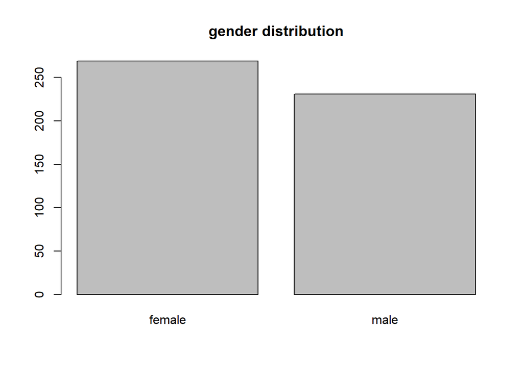

```r
# bar plot
## distribution of gender for those who clicked ads
gender_dist<- table(clicks$Male)
label<- c("female","male")
barplot(gender_dist,names.arg=label,main="gender distribution")
```

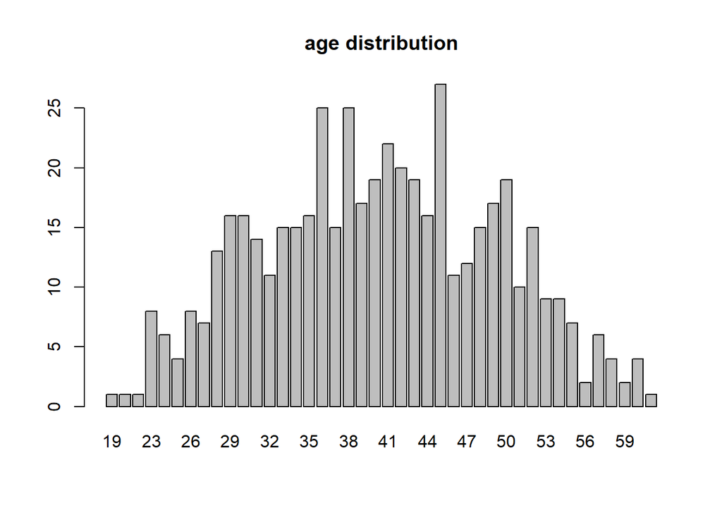

```r
## age distribution
age_dist<- table(clicks$Age)
barplot(age_dist,main="age distribution")
```

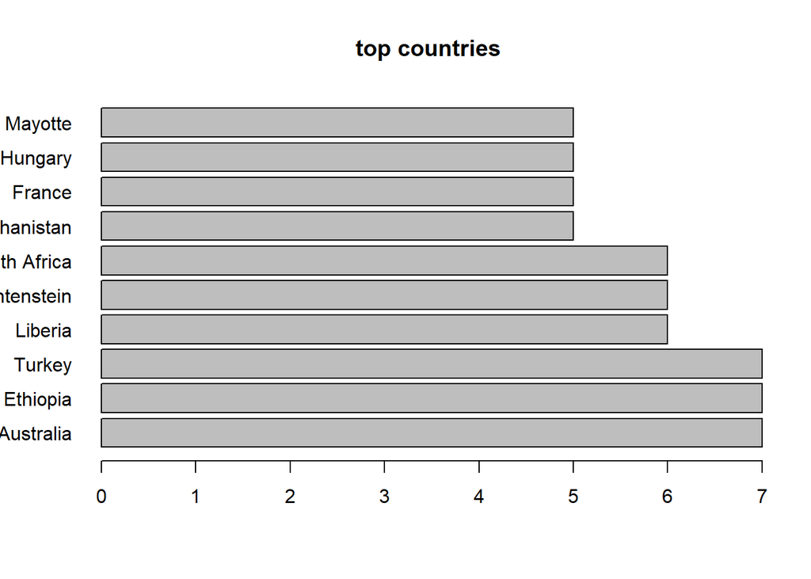

```r
## distribution for countries
topcountries<- head(sort(table(clicks$Country),decreasing=TRUE),n=10)
barplot(topcountries,las=1, main="top countries",horiz=TRUE)
```

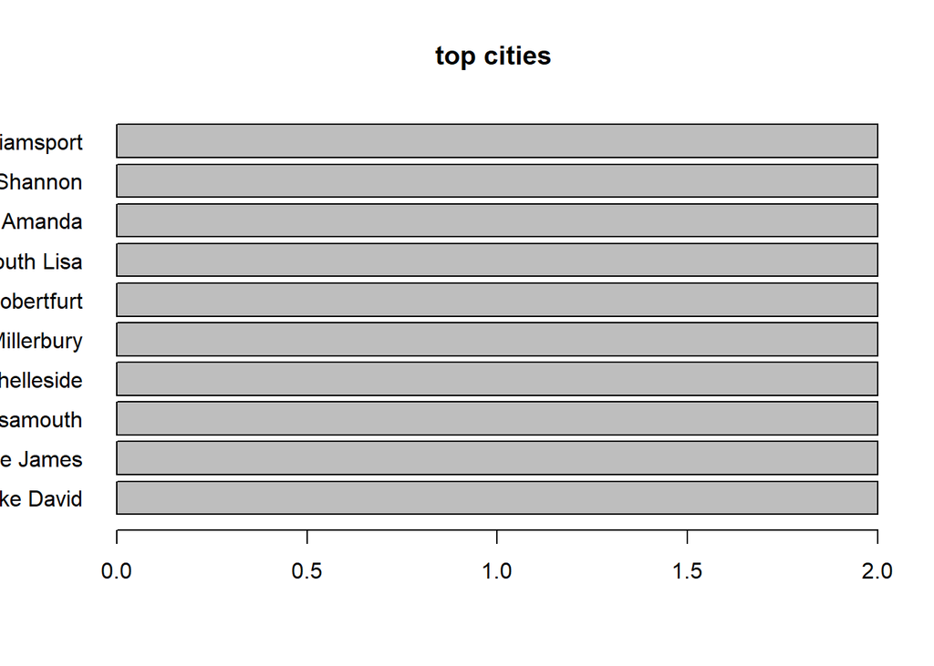

```r
## distribution for countries
topcities<- head(sort(table(clicks$City),decreasing=TRUE),n=10)
barplot(topcities,las=1, main="top cities",horiz=TRUE)
```

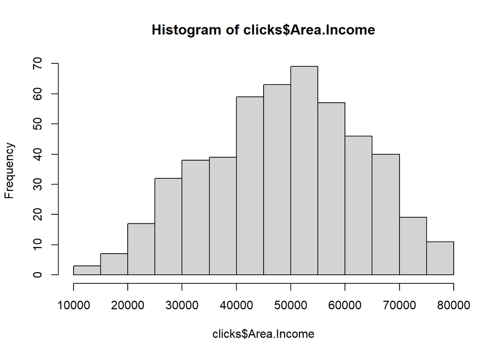

```r
hist(clicks$Area.Income)
```

1. Australia, Ethiopia and Turkey top the list of the countries with the most clicks. 2. People aged 45 had the most clicks among all closely followed by those aged 36 and 38 years. 3. Females beat their male counterparts in the number of ads clicked. 4. The areas that have an income between 40000 and 70000 have the most clicks on the ads

## BIVARIATE ANALYSIS

```r
# correlation heatmap for numerical columns
cor(ads[sapply(ads,is.numeric)])
```

```
##                          Daily.Time.Spent.on.Site         Age  Area.Income
## Daily.Time.Spent.on.Site               1.00000000 -0.33151334  0.310954413
## Age                                   -0.33151334  1.00000000 -0.182604955
## Area.Income                            0.31095441 -0.18260496  1.000000000
## Daily.Internet.Usage                   0.51865848 -0.36720856  0.337495533
## Male                                  -0.01895085 -0.02104406  0.001322359
## Clicked.on.Ad                         -0.74811656  0.49253127 -0.476254628
##                          Daily.Internet.Usage         Male Clicked.on.Ad
## Daily.Time.Spent.on.Site           0.51865848 -0.018950855   -0.74811656
## Age                               -0.36720856 -0.021044064    0.49253127
## Area.Income                        0.33749553  0.001322359   -0.47625463
## Daily.Internet.Usage               1.00000000  0.028012326   -0.78653918
## Male                               0.02801233  1.000000000   -0.03802747
## Clicked.on.Ad                     -0.78653918 -0.038027466    1.00000000
```

```r
### Covariance between the Daily_Time_Spent_on_Site and Clicked_on_Ad
cov(ads$Daily.Time.Spent.on.Site, ads$Clicked.on.Ad)
```

```
## [1] -5.933143
```

```r
### Covariance between the Age and Area Income and Clicked_on_Ad
cov(ads$Age, ads$Clicked.on.Ad)
```

```
## [1] 2.164665
```

```r
### Covariance between the Area_Income and Age and Clicked_on_Ad
cov(ads$Area.Income, ads$Clicked.on.Ad)
```

```
## [1] -3195.989
```

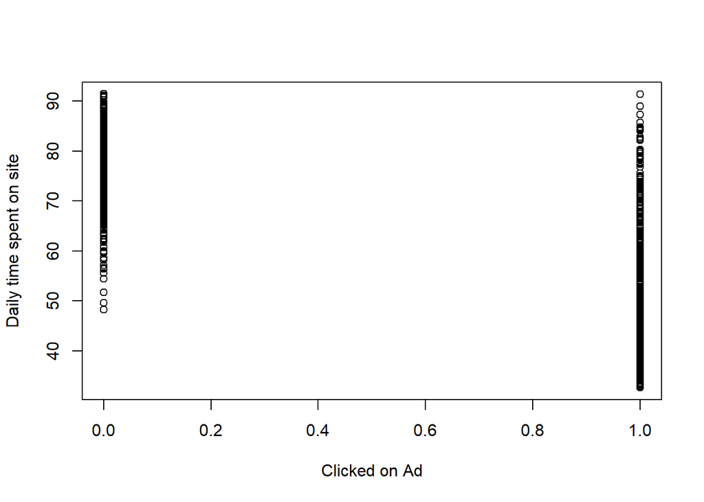

```r
## Scatter plots
plot(ads$Clicked.on.Ad, ads$Daily.Time.Spent.on.Site, xlab="Clicked on Ad", ylab="Daily time spent on site")
```

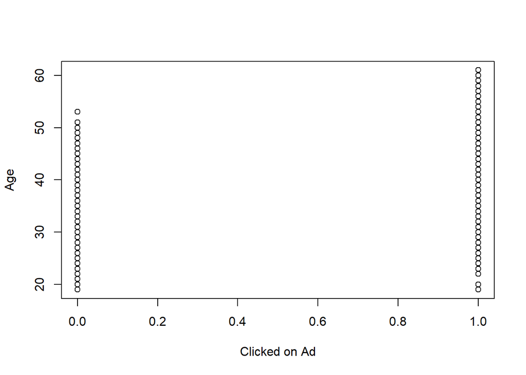

```r
plot(ads$Clicked.on.Ad, ads$Age, xlab="Clicked on Ad", ylab="Age")
```

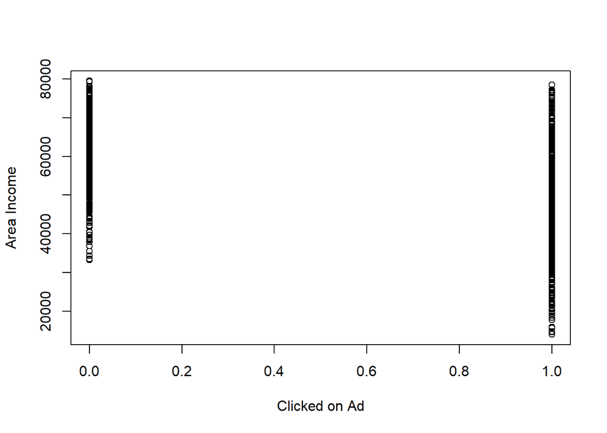

```r
plot(ads$Clicked.on.Ad, ads$Area.Income, xlab="Clicked on Ad", ylab="Area Income")
```

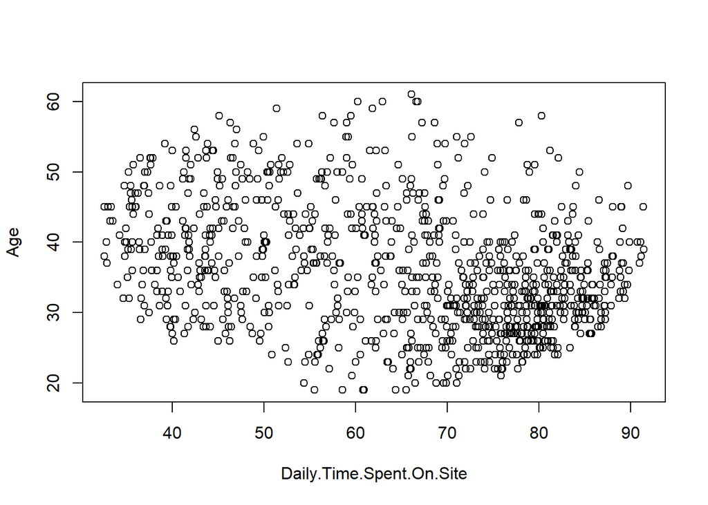

```r
plot(ads$Daily.Time.Spent.on.Site, ads$Age, xlab="Daily.Time.Spent.On.Site", ylab="Age")
```

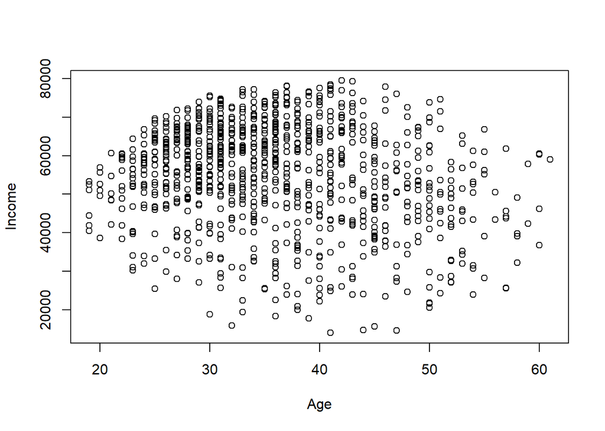

```r
plot(ads$Age, ads$Area.Income, xlab="Age", ylab="Income")
```

## RECOMMENDATIONS

# K-Nearest Neighbors

```r
# Convert the labels to categorical
ads$Clicked.on.Ad <- factor(ads$Clicked.on.Ad)
```

```r
round(prop.table(table(ads$Clicked.on.Ad)) * 100, digits = 1)
```

```
##
##  0  1
## 50 50
```

We don’t have a case of class imbalance in our labels.

```r
# Let's look at the features we'll be using in our modelling
head(ads)
```

```
##   Daily.Time.Spent.on.Site Age Area.Income Daily.Internet.Usage
## 1                    68.95  35    61833.90               256.09
## 2                    80.23  31    68441.85               193.77
## 3                    69.47  26    59785.94               236.50
## 4                    74.15  29    54806.18               245.89
## 5                    68.37  35    73889.99               225.58
## 6                    59.99  23    59761.56               226.74
##                           Ad.Topic.Line           City Male    Country
## 1    Cloned 5thgeneration orchestration    Wrightburgh    0    Tunisia
## 2    Monitored national standardization      West Jodi    1      Nauru
## 3      Organic bottom-line service-desk       Davidton    0 San Marino
## 4 Triple-buffered reciprocal time-frame West Terrifurt    1      Italy
## 5         Robust logistical utilization   South Manuel    0    Iceland
## 6       Sharable client-driven software      Jamieberg    1     Norway
##             Timestamp Clicked.on.Ad
## 1 2016-03-27 00:53:11             0
## 2 2016-04-04 01:39:02             0
## 3 2016-03-13 20:35:42             0
## 4 2016-01-10 02:31:19             0
## 5 2016-06-03 03:36:18             0
## 6 2016-05-19 14:30:17             0
```

```r
unique(ads[c("City")])
```

```
##                         City
## 1                Wrightburgh
## 2                  West Jodi
## 3                   Davidton
## 4             West Terrifurt
## 5               South Manuel
## 6                  Jamieberg
## 7                Brandonstad
## 8           Port Jefferybury
## 9                 West Colin
## 10                Ramirezton
## 11           West Brandonton
## 12         East Theresashire
## 13            West Katiefurt
## 14                North Tara
```

[output cut: 955 more lines]

```r
unique(ads[c("Country")])
```

```
##                                                 Country
## 1                                               Tunisia
## 2                                                 Nauru
## 3                                            San Marino
## 4                                                 Italy
## 5                                               Iceland
## 6                                                Norway
## 7                                               Myanmar
## 8                                             Australia
## 9                                               Grenada
## 10                                                Ghana
## 11                                                Qatar
## 12                                              Burundi
## 13                                                Egypt
## 14                               Bosnia and Herzegovina
```

[output cut: 223 more lines]

```r
# Feature selection
ad <- ads[c('Daily.Time.Spent.on.Site', 'Age', 'Area.Income', 'Daily.Internet.Usage', 'Male', 'Clicked.on.Ad')]
```

```r
str(ad)
```

```
## 'data.frame':    1000 obs. of  6 variables:
##  $ Daily.Time.Spent.on.Site: num  69 80.2 69.5 74.2 68.4 ...
##  $ Age                     : int  35 31 26 29 35 23 33 48 30 20 ...
##  $ Area.Income             : num  61834 68442 59786 54806 73890 ...
##  $ Daily.Internet.Usage    : num  256 194 236 246 226 ...
##  $ Male                    : int  0 1 0 1 0 1 0 1 1 1 ...
##  $ Clicked.on.Ad           : Factor w/ 2 levels "0","1": 1 1 1 1 1 1 1 2 1 1 ...
```

```r
# Looking at the dataframe we'll be working with
head(ad)
```

```
##   Daily.Time.Spent.on.Site Age Area.Income Daily.Internet.Usage Male
## 1                    68.95  35    61833.90               256.09    0
## 2                    80.23  31    68441.85               193.77    1
## 3                    69.47  26    59785.94               236.50    0
## 4                    74.15  29    54806.18               245.89    1
## 5                    68.37  35    73889.99               225.58    0
## 6                    59.99  23    59761.56               226.74    1
##   Clicked.on.Ad
## 1             0
## 2             0
## 3             0
## 4             0
## 5             0
## 6             0
```

```r
#Normalization
normalize <- function(x) {
return ((x - min(x)) / (max(x) - min(x))) }
```

We’ll normalize our data but we will remove the Clicked on ad variable since it’s the response variable we will be predicting.

```r
ad_norm <- as.data.frame(lapply(ad[,1:5], normalize))

# The normalized data
head(ad_norm)
```

```
##   Daily.Time.Spent.on.Site       Age Area.Income Daily.Internet.Usage Male
## 1                0.6178820 0.3809524   0.7304725            0.9160310    0
## 2                0.8096209 0.2857143   0.8313752            0.5387456    1
## 3                0.6267211 0.1666667   0.6992003            0.7974331    0
## 4                0.7062723 0.2380952   0.6231599            0.8542802    1
## 5                0.6080231 0.3809524   0.9145678            0.7313234    0
## 6                0.4655788 0.0952381   0.6988280            0.7383460    1
```

```r
set.seed(1234)
#random selection of 70% data.
ad_data <- sample(1:nrow(ad_norm),size=nrow(ad_norm)*0.7,replace = FALSE)

train <- ad[ad_data,]
test <- ad[-ad_data,]
```

```r
train_label <- ad[ad_data,6]
test_label <-ad[-ad_data,6]
```

##BUILDING THE MODEL

```r
# Load class package
library(class)
```

```r
#Find the number of observation
NROW(train_label)
```

```
## [1] 700
```

```r
# Instantiate the knn function
knn <- knn(train=train, test=test, cl=train_label, k=26)

# Load the library for checking the confusion matrix
library(caret)
# Accuracy
library(e1071)
confusionMatrix(table(knn,test_label))
```

```
## Confusion Matrix and Statistics
##
##    test_label
## knn   0   1
##   0 110  53
##   1  42  95
##
##                Accuracy : 0.6833
##                  95% CI : (0.6274, 0.7356)
##     No Information Rate : 0.5067
##     P-Value [Acc > NIR] : 4.241e-10
##
##                   Kappa : 0.3659
##
##  Mcnemar's Test P-Value : 0.3049
##
##             Sensitivity : 0.7237
##             Specificity : 0.6419
##          Pos Pred Value : 0.6748
##          Neg Pred Value : 0.6934
##              Prevalence : 0.5067
##          Detection Rate : 0.3667
##    Detection Prevalence : 0.5433
##       Balanced Accuracy : 0.6828
##
##        'Positive' Class : 0
##
```

## Challenging the solution using a different classification model

# SVM

```r
intrain <- createDataPartition(y = ad$Clicked.on.Ad, p= 0.7, list = FALSE)
train <- ad[intrain,]
test <- ad[-intrain,]
```

```r
# Ensuring the variabke to be predicted is categorical
train[["Clicked.on.Ad"]] = factor(train[["Clicked.on.Ad"]])
```

```r
# Train control to train data on different algorithm
tr_ctl <- trainControl(method = "repeatedcv", number = 10, repeats = 5)

library(kernlab)
svm_Linear <- train(Clicked.on.Ad ~., data = train, method = "svmLinear",
trControl=tr_ctl,
preProcess = c("center", "scale"),
tuneLength = 10)
```

```r
test_pred <- predict(svm_Linear, newdata = test)
confusionMatrix(table(test_pred, test$Clicked.on.Ad))
```

```
## Confusion Matrix and Statistics
##
##
## test_pred   0   1
##         0 146   7
##         1   4 143
##
##                Accuracy : 0.9633
##                  95% CI : (0.9353, 0.9816)
##     No Information Rate : 0.5
##     P-Value [Acc > NIR] : <2e-16
##
##                   Kappa : 0.9267
##
##  Mcnemar's Test P-Value : 0.5465
##
##             Sensitivity : 0.9733
##             Specificity : 0.9533
##          Pos Pred Value : 0.9542
##          Neg Pred Value : 0.9728
##              Prevalence : 0.5000
##          Detection Rate : 0.4867
##    Detection Prevalence : 0.5100
##       Balanced Accuracy : 0.9633
##
##        'Positive' Class : 0
##
```

For our classification model, the best one in classifying whether an individual will click the ad or not we will go with SVM since it gives us the better accuracy compared to KNN.